# Who consider online dating is more successful, Guys or Girls?

Author

Ivan Cheng

## Start from: Create concrete steps to follow for each phase of the project and do it!

# Introduction

“Which gender consider online dating would be more successful, actually?” Most of people would think female receive more attentions on the dating apps, however, is that true? Moreover, more attentions don’t equal to more success on relationship. Thus, to remove the mystery of this question. I decided to design a research on the success among genders on online dating topic.

# Design the Study

First of all, our final research question would be: “Compared to in-person relationship, which gender considers online dating is more successful? Male or Female?” Since we don’t have the exact data for the users’ real relational experiences, we can still take their opinion as an indicator. We will use the data collected by Pew Researching Center and mainly focus on US residents. Although most people might regard female could receive attentions more easily, however, more attentions don’t equal to more successes.

# Collect the Data

To the collect the data, I will research on 2 kinds of categorical variables: 1. (Response Variable) The relationship starts from online dating is : More successful, Less successful,or Just as successful? 2. (Explanatory Variable) Is your partner a : Female,or Male? To simplify the research, we don’t consider the LGBTQ sections in this research. I think that also why the original data set will use the orientation to define testers’ gender. In this case, I will only focus on the people who answered straight for their sexual orientation and use their answers on partner sex to define their sex reversely. Since I’m focusing on the categorical variables, I would use Chi-square test for independence and proportion table comparison to conduct the test.

# Describe/Summarize the Data

Notes for each column meaning and restriction

ONSUCCESS_W56 (More successful, Less successful, Just as successful) PARTNERSEX_W56, 1 = female; 2 = male (Their partner sex 1 == male, thus the tester who chose 1 is female, 2 is male) filter: ORIENTATIONMOD_W56 == 2(straight, not LGBTQ),

```r
library(tidyverse)
library(mosaic)
library(rio)
library(ggplot2)
library(car)
# Be sure to make this using ggplot()

# Session -> Set working directory ->To Source File location
# Or: More -> Copy folder path to Clipboard
data <- import("C:/Users/calla/桌面/programming/MATH 221D/MATH 221D/6-Semester_Project/ATP W56.sav")
glimpse(data)
```

```
Rows: 4,860
Columns: 183
$ QKEY                     <dbl> 25, 26, 27, 28, 29, 39, 45, 46, 76, 80, 93, 1…
$ INTERVIEW_START_W56      <dttm> 2019-10-16 20:02:03, 2019-10-16 20:02:40, 20…
$ INTERVIEW_END_W56        <dttm> 2019-10-16 20:08:29, 2019-10-16 20:09:06, 20…
$ DEVICE_TYPE_W56          <dbl> 3, 3, 3, 1, 3, 3, 3, 3, 1, 1, 3, 2, 3, 1, 3, …
$ SAMPLE_W56               <dbl> 2, 2, 2, 2, 2, 2, 2, 2, 2, 2, 2, 2, 2, 2, 2, …
$ FORM_W56                 <dbl> 2, 2, 1, 2, 1, 1, 2, 2, 2, 1, 1, 1, 2, 2, 1, …
$ MARITAL_W56              <dbl> 1, 6, 6, 1, 6, 2, 2, 6, 1, 2, 6, 6, 2, 6, 6, …
$ MARITAL2_W56             <dbl> NA, 2, 1, NA, 2, NA, NA, 2, NA, NA, 2, 2, NA,…
$ RELATEVER_W56            <dbl> NA, 2, NA, NA, 1, NA, NA, 1, NA, NA, 1, 1, NA…
$ CASUAL_W56               <dbl> NA, 2, NA, NA, 2, NA, NA, 2, NA, NA, 2, 1, NA…
$ SEEKING_W56              <dbl> NA, 4, NA, NA, 3, NA, NA, 1, NA, NA, 1, 2, NA…
$ MOTIVNODATE.a_W56        <dbl> NA, 1, NA, NA, NA, NA, NA, NA, NA, NA, NA, NA…
$ MOTIVNODATE.b_W56        <dbl> NA, 1, NA, NA, NA, NA, NA, NA, NA, NA, NA, NA…
```

[output cut: 170 more lines]

```r
dating <- data %>%
  filter(ORIENTATIONMOD_W56 == 2, # filter out the orientation isn't straight
         ONSUCCESS_W56 %in% c(1, 2, 3), # filter out the NA and bad values
         PARTNERSEX_W56 %in% c(1, 2)) %>%  # filter out the NA and bad values
  select(ONSUCCESS_W56, PARTNERSEX_W56) # only select 2 columns for online dating successful opinion and partner sex(for later define testers' sex.)


glimpse(dating)
```

```
Rows: 2,011
Columns: 2
$ ONSUCCESS_W56  <dbl> 2, 2, 2, 3, 1, 3, 2, 3, 3, 3, 2, 3, 3, 3, 3, 3, 2, 2, 3…
$ PARTNERSEX_W56 <dbl> 1, 1, 2, 2, 1, 2, 1, 1, 2, 1, 2, 2, 1, 1, 1, 1, 1, 1, 1…
```

```r
table(dating$ONSUCCESS_W56)
```

```
   1    2    3
  99  739 1173
```

```r
table(dating$PARTNERSEX_W56)
```

```
   1    2
1066  945
```

```r
dating_mutate <- dating %>% # Change the column names for easier understanding
  mutate(
    on_date_success = case_when(
      ONSUCCESS_W56 == 1 ~ "More successful",
      ONSUCCESS_W56 == 2 ~ "Less successful",
      ONSUCCESS_W56 == 3 ~ "Just as successful"
    ),
    sex = case_when(
      PARTNERSEX_W56 == 1 ~ "female",
      PARTNERSEX_W56 == 2 ~ "male"
    )
  )

glimpse(dating_mutate)
```

```
Rows: 2,011
Columns: 4
$ ONSUCCESS_W56   <dbl> 2, 2, 2, 3, 1, 3, 2, 3, 3, 3, 2, 3, 3, 3, 3, 3, 2, 2, …
$ PARTNERSEX_W56  <dbl> 1, 1, 2, 2, 1, 2, 1, 1, 2, 1, 2, 2, 1, 1, 1, 1, 1, 1, …
$ on_date_success <chr> "Less successful", "Less successful", "Less successful…
$ sex             <chr> "female", "female", "male", "male", "female", "male", …
```

# Make Inference

Use addmargins() & prop.table() functions to have the propositions and percentages on levels of success of female/ male responses.

```r
# Perform the appropriate test for the data selected
dating_table <- table(dating_mutate$on_date_success, dating_mutate$sex)
dating_table
```

```
                     female male
  Just as successful    643  530
  Less successful       388  351
  More successful        35   64
```

```r
addmargins(dating_table)
```

```
                     female male  Sum
  Just as successful    643  530 1173
  Less successful       388  351  739
  More successful        35   64   99
  Sum                  1066  945 2011
```

```r
prop.table(dating_table, margin = 1)
```

```
                        female      male
  Just as successful 0.5481671 0.4518329
  Less successful    0.5250338 0.4749662
  More successful    0.3535354 0.6464646
```

```r
prop.table(dating_table, margin = 2)
```

```
                         female       male
  Just as successful 0.60318949 0.56084656
  Less successful    0.36397749 0.37142857
  More successful    0.03283302 0.06772487
```

[figure not shown]

```r
# The bar chart based on proportions
ggplot(dating_mutate, aes(x = on_date_success, fill = sex)) +
  geom_bar(position = "dodge") +
  labs(
    title = "Male Regards Online Dating Is More Successful Than Female Does(proportions)"
  ) +
  theme_bw()
```

Create a column graph to compare online dating successful difference on sex(based on percentages):

```r
# create a data set based on percentage first
dating_prop <- as.data.frame(prop.table(dating_table, margin = 1))

glimpse(dating_prop)
```

```
Rows: 6
Columns: 3
$ Var1 <fct> Just as successful, Less successful, More successful, Just as suc…
$ Var2 <fct> female, female, female, male, male, male
$ Freq <dbl> 0.5481671, 0.5250338, 0.3535354, 0.4518329, 0.4749662, 0.6464646
```

```r
view(dating_prop)

# use mutate() to change column names
names(dating_prop) <- c("on_date_success", "sex", "percentage")
glimpse(dating_prop)
```

```
Rows: 6
Columns: 3
$ on_date_success <fct> Just as successful, Less successful, More successful, …
$ sex             <fct> female, female, female, male, male, male
$ percentage      <dbl> 0.5481671, 0.5250338, 0.3535354, 0.4518329, 0.4749662,…
```

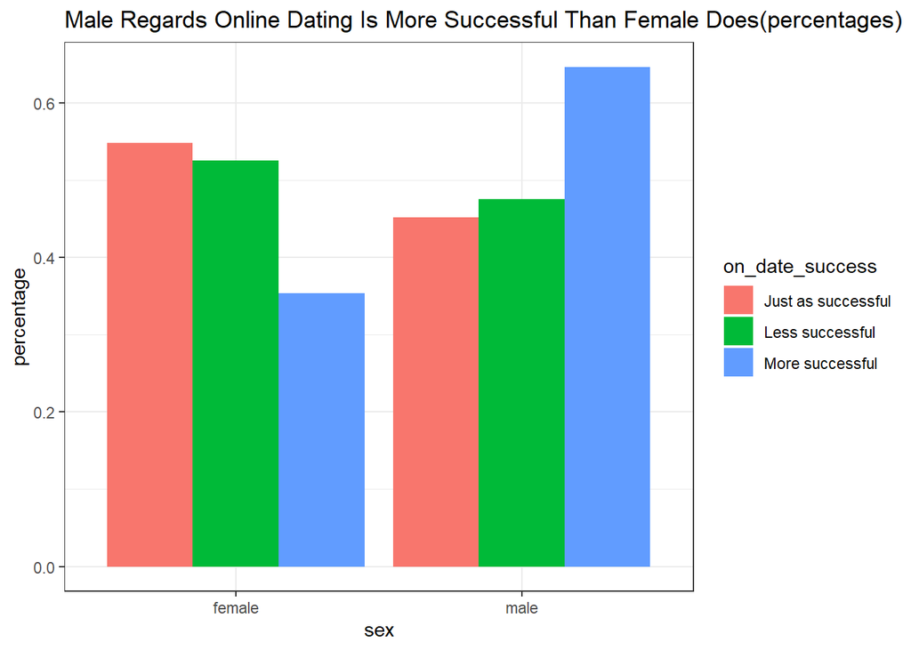

```r
# create the column chart based on percentages
ggplot(dating_prop, aes(x = sex ,y = percentage, fill = on_date_success)) +
  geom_col(position = "dodge") +
  labs(
    title = "Male Regards Online Dating Is More Successful Than Female Does(percentages)"
  ) +
  theme_bw()
```

State Null Hypothesis and Alternative Hypothesis:

$$H_0: \text{Your opinion on how successful online dating is is independent of your sex}$$
$$H_a: \text{Your opinion on how successful online dating is is not independent of your sex}$$

Conduct Chi-Square Test on prop.table

```r
chisq.test(dating_table)
```

```
    Pearson's Chi-squared test

data:  dating_table
X-squared = 14.003, df = 2, p-value = 0.0009103
```

P-value: 0.0009103, less than alpha value 0.05. Thus, we reject the Null Hypothesis and receive the Alternative Hypothesis.

## Degree of freedom: 2

Check if p-value is valid (if all of the counts are greater than 5)

```r
chisq.test(dating_table)$expected >= 5
```

```
                     female male
  Just as successful   TRUE TRUE
  Less successful      TRUE TRUE
  More successful      TRUE TRUE
```

validity examination: Passed.

# Conclusion (Take Action)

Conclusion: I have sufficient evidence to suggest that your opinion on how successful online dating is is not independent of your sex.

From the research, we can see more males consider online dating would be successful than female. Thus, go back to the beginning question: “Compared to in-person relationship, which gender considers online dating is more successful? Male or Female?” The answer is Male.

Actions: As we know that more males consider the online dating would be more successful than female, we should focus on male party when we talk about the disadvantages of online dating. Since males are more likely to have higher relationship success expectation on online dating, we should put more resources and assistance on male who had some issues and challenges on online dating topic.